# Logistic Regression Using General Additive Model

[Sushank Pokhrel (Homepage)](https://sushank.com.np)

We are performing logistic regression using General Additive Model (GAM). A Generalized Additive Model (GAM) is a statistical model used in data analysis. It extends generalized linear models (GLMs) by allowing for non-linear relationships between the independent variables and the dependent variable. Unlike linear regression, which assumes a straight-line relationship between variables, GAMs allow for more flexible modeling of relationships.

**Please go through the GLM tutorial before this.**

### 1. Preparing the Data

#### A. Importing the data.

```r
chd_data <- read.csv("D:/Drive/r_training/Datasets/framingham.csv")
```

The dataset is read into R from a CSV file and assigned to chd_data. The Framingham dataset is widely used for modeling coronary heart disease (CHD) risk factors. It is available at Kaggle.

#### B. Inspecting the Data

```r
head(chd_data)
```

```
##   male age education currentSmoker cigsPerDay BPMeds prevalentStroke
## 1    1  39         4             0          0      0               0
## 2    0  46         2             0          0      0               0
## 3    1  48         1             1         20      0               0
## 4    0  61         3             1         30      0               0
## 5    0  46         3             1         23      0               0
## 6    0  43         2             0          0      0               0
##   prevalentHyp diabetes totChol sysBP diaBP   BMI heartRate glucose TenYearCHD
## 1            0        0     195 106.0    70 26.97        80      77          0
## 2            0        0     250 121.0    81 28.73        95      76          0
## 3            0        0     245 127.5    80 25.34        75      70          0
## 4            1        0     225 150.0    95 28.58        65     103          1
## 5            0        0     285 130.0    84 23.10        85      85          0
## 6            1        0     228 180.0   110 30.30        77      99          0
```

```r
str(chd_data)
```

```
## 'data.frame':    4238 obs. of  16 variables:
##  $ male           : int  1 0 1 0 0 0 0 0 1 1 ...
##  $ age            : int  39 46 48 61 46 43 63 45 52 43 ...
##  $ education      : int  4 2 1 3 3 2 1 2 1 1 ...
##  $ currentSmoker  : int  0 0 1 1 1 0 0 1 0 1 ...
##  $ cigsPerDay     : int  0 0 20 30 23 0 0 20 0 30 ...
##  $ BPMeds         : int  0 0 0 0 0 0 0 0 0 0 ...
##  $ prevalentStroke: int  0 0 0 0 0 0 0 0 0 0 ...
##  $ prevalentHyp   : int  0 0 0 1 0 1 0 0 1 1 ...
##  $ diabetes       : int  0 0 0 0 0 0 0 0 0 0 ...
##  $ totChol        : int  195 250 245 225 285 228 205 313 260 225 ...
##  $ sysBP          : num  106 121 128 150 130 ...
##  $ diaBP          : num  70 81 80 95 84 110 71 71 89 107 ...
##  $ BMI            : num  27 28.7 25.3 28.6 23.1 ...
##  $ heartRate      : int  80 95 75 65 85 77 60 79 76 93 ...
##  $ glucose        : int  77 76 70 103 85 99 85 78 79 88 ...
##  $ TenYearCHD     : int  0 0 0 1 0 0 1 0 0 0 ...
```

```r
colnames(chd_data)
```

```
##  [1] "male"            "age"             "education"       "currentSmoker"
##  [5] "cigsPerDay"      "BPMeds"          "prevalentStroke" "prevalentHyp"
##  [9] "diabetes"        "totChol"         "sysBP"           "diaBP"
## [13] "BMI"             "heartRate"       "glucose"         "TenYearCHD"
```

- head(): Displays the first few rows of the dataset for an overview of its structure.
- str(): Summarizes the structure of the dataset, showing the type and sample values of each column.
- colnames(): Lists all column names, helping identify available variables.

#### C. Preprocessing

```r
library(tidyverse)
chd <- chd_data |>
  dplyr::mutate(
    male = as.factor(male),
    education = as.factor(education),
    currentSmoker = as.factor(currentSmoker),
    BPMeds = as.factor(BPMeds),
    prevalentHyp = as.factor(prevalentHyp),
    diabetes = as.factor(diabetes),
    prevalentStroke = as.factor(prevalentStroke),
    TenYearCHD = as.factor(TenYearCHD)
  ) |>
  dplyr::select(
    male, education, currentSmoker, BPMeds, prevalentHyp, diabetes, prevalentStroke, TenYearCHD,
    sysBP, diabetes, BMI, heartRate, glucose, diaBP, cigsPerDay, age
  ) |>
  na.omit()
```

- Converts categorical variables into factors for proper interpretation in the logistic regression model.
- `dplyr::select()`: Selects relevant columns for analysis.
- `na.omit()`: Removes rows with missing values.

### 2. Building the Logistic Regression Model

#### A. Initial Model

```r
library(mgcv)
logit_chd <- gam(
  data = chd,
  formula = TenYearCHD ~ sysBP + diaBP + BMI + heartRate + glucose + cigsPerDay + age + education + prevalentStroke + prevalentHyp,
  family = binomial
)

summary(logit_chd)
```

```
##
## Family: binomial
## Link function: logit
##
## Formula:
## TenYearCHD ~ sysBP + diaBP + BMI + heartRate + glucose + cigsPerDay +
##     age + education + prevalentStroke + prevalentHyp
##
## Parametric coefficients:
##                    Estimate Std. Error z value Pr(>|z|)
## (Intercept)      -7.5389167  0.6491314 -11.614  < 2e-16 ***
## sysBP             0.0135458  0.0037238   3.638 0.000275 ***
## diaBP            -0.0008912  0.0063688  -0.140 0.888714
## BMI               0.0068710  0.0124173   0.553 0.580028
## heartRate        -0.0049260  0.0041638  -1.183 0.236784
## glucose           0.0075320  0.0016665   4.520 6.19e-06 ***
## cigsPerDay        0.0277027  0.0039475   7.018 2.25e-12 ***
## age               0.0647450  0.0066838   9.687  < 2e-16 ***
## education2       -0.2281803  0.1224558  -1.863 0.062410 .
## education3       -0.2326435  0.1486403  -1.565 0.117549
## education4        0.0020047  0.1636464   0.012 0.990226
## prevalentStroke1  0.7518156  0.4878030   1.541 0.123261
## prevalentHyp1     0.2554484  0.1378899   1.853 0.063946 .
## ---
## Signif. codes:  0 '***' 0.001 '**' 0.01 '*' 0.05 '.' 0.1 ' ' 1
##
##
## R-sq.(adj) =  0.0992   Deviance explained = 10.9%
## UBRE = -0.233  Scale est. = 1         n = 3665
```

- Predict whether an individual develops CHD in 10 years (TenYearCHD), using various risk factors as predictors.

Formula:

- Dependent variable: TenYearCHD (binary outcome: 0 = no CHD, 1 = CHD).
- Predictors: Blood pressure (sysBP, diaBP), BMI, heart rate, glucose, cigarette consumption, age, education, history of stroke, and hypertension.
- `family = binomial`: Specifies logistic regression (binary outcome).
- `summary()`: Provides model details, including coefficients, significance levels, and goodness-of-fit metrics.

#### B. Selecting only the necessary ones.

As we are pretty sure that the mentioned predictor variables best predict the prevalence of coronary heart disease, lets perform the test, we can select only the necessary predictors for our ease.

```r
chd_predictors <- chd |>
  dplyr::select(
    sysBP, glucose, cigsPerDay, age, TenYearCHD
  )
```

#### C. Refined Model

```r
logit_chd <- gam(
  data = chd,
  formula = TenYearCHD ~ sysBP + glucose + cigsPerDay + age,
  family = binomial
)
summary(logit_chd)
```

```
##
## Family: binomial
## Link function: logit
##
## Formula:
## TenYearCHD ~ sysBP + glucose + cigsPerDay + age
##
## Parametric coefficients:
##              Estimate Std. Error z value Pr(>|z|)
## (Intercept) -8.404189   0.410559 -20.470  < 2e-16 ***
## sysBP        0.016724   0.002108   7.933 2.13e-15 ***
## glucose      0.007385   0.001666   4.432 9.32e-06 ***
## cigsPerDay   0.027101   0.003918   6.918 4.58e-12 ***
## age          0.068405   0.006386  10.712  < 2e-16 ***
## ---
## Signif. codes:  0 '***' 0.001 '**' 0.01 '*' 0.05 '.' 0.1 ' ' 1
##
##
## R-sq.(adj) =  0.0966   Deviance explained = 10.5%
## UBRE = -0.23363  Scale est. = 1         n = 3665
```

### 3. Testing Multicollinearity

#### Correlation Matrix

Examines correlations between continuous predictors to identify multicollinearity (high correlations indicate redundancy). Pearson correlation matrix is used to test the correlation and the parameters with correlation coefficient greater than 0.7 (r>|0.7|) are removed.

```r
cor(chd[, c("sysBP", "glucose", "cigsPerDay", "age")])
```

```
##                  sysBP     glucose  cigsPerDay        age
## sysBP       1.00000000  0.13452844 -0.09484538  0.3877183
## glucose     0.13452844  1.00000000 -0.05436434  0.1182034
## cigsPerDay -0.09484538 -0.05436434  1.00000000 -0.1892074
## age         0.38771829  0.11820342 -0.18920738  1.0000000
```

None of the parameters are highly correlated.

#### Variance Inflation Factor (VIF)

```r
car::vif(logit_chd)
```

```
##                GVIF Df GVIF^(1/(2*Df))
## sysBP      1.201567  0             Inf
## glucose    1.201567  0             Inf
## cigsPerDay 1.201567  0             Inf
## age        1.201567  0             Inf
```

- VIF > 10: High multicollinearity (problematic).
- VIF < 5: Acceptable range. (VIF<10 is considered in some literatures.)

### 4. Splitting Data into Training and Testing Sets

As the above parameters are working properly, we now split the data into training and testing sets, where model training is done by using 70% of the data and testing is done by using the 30% of the data.

```r
set.seed(123)

train_indices <- sample(1:nrow(chd_predictors), 0.7 * nrow(chd_predictors))
train_data <- chd_predictors[train_indices, ]
test_data <- chd_predictors[-train_indices, ]
```

- `set.seed(123)`: Ensures reproducibility by fixing the random sampling.

### 5. Logistic Regression on Training Data

#### A. Performing the regression analaysis.

Logistic regression model fit on the training data to predict CHD.

```r
reg_test <- gam(
  data = train_data,
  formula = TenYearCHD ~ sysBP + glucose + cigsPerDay + age,
  family = binomial
)

summary(reg_test)
```

```
##
## Family: binomial
## Link function: logit
##
## Formula:
## TenYearCHD ~ sysBP + glucose + cigsPerDay + age
##
## Parametric coefficients:
##              Estimate Std. Error z value Pr(>|z|)
## (Intercept) -8.776088   0.490025 -17.909  < 2e-16 ***
## sysBP        0.017743   0.002493   7.118 1.09e-12 ***
## glucose      0.006861   0.001958   3.504 0.000459 ***
## cigsPerDay   0.030452   0.004678   6.510 7.53e-11 ***
## age          0.073075   0.007655   9.546  < 2e-16 ***
## ---
## Signif. codes:  0 '***' 0.001 '**' 0.01 '*' 0.05 '.' 0.1 ' ' 1
##
##
## R-sq.(adj) =  0.113   Deviance explained = 11.9%
## UBRE = -0.23953  Scale est. = 1         n = 2565
```

#### B. Predicting Probabilities

```r
chd_train <- train_data

chd_train$predicted_prob <- predict(reg_test, type = "response")
chd_train <- chd_train %>% mutate(predicted_class = ifelse(predicted_prob > 0.5, 1, 0))

head(chd_train, n = 20)
```

```
##      sysBP glucose cigsPerDay age TenYearCHD predicted_prob predicted_class
## 2855 111.0      44         40  59          0     0.27384053               0
## 2913 125.0      93          0  39          0     0.04435269               0
## 2581 131.0      73          0  54          0     0.11869461               0
## 606  145.0      86          9  64          0     0.34019159               0
## 219  123.0      74          0  57          0     0.12778208               0
## 3463 123.0      78          0  57          1     0.13087204               0
## 2149 148.0      60          0  52          0     0.12580716               0
## 1316 114.0      59          0  60          0     0.12302511               0
## 3908 112.0      60          0  42          0     0.03529579               0
## 1444 141.0      85         30  38          0     0.11912728               0
## 1461 117.5      75         30  54          0     0.21130053               0
## 1194 127.0      78          0  64          1     0.21235720               0
## 3996 118.0      71         15  41          0     0.06051592               0
## 762   96.5      68         10  42          0     0.03828446               0
## 3078 111.0      63          0  67          1     0.18567596               0
## 1880 115.0      99          0  61          0     0.16814311               0
## 3209 137.5      68          0  37          0     0.04046198               0
## 1160 144.0      82          0  60          0     0.21857448               0
## 1282 108.0      70          0  41          0     0.03281515               0
## 1092 112.0      84         30  47          1     0.13418308               0
```

- `predict()`: Computes predicted probabilities of CHD for each individual.
- `ifelse()`: Converts probabilities into binary predictions (threshold = 0.5).

#### C.Evaluating Model Performance

##### Confusion Matrix

```r
confusion_train <- table(chd_train$TenYearCHD, chd_train$predicted_class)
confusion_train
```

```
##
##        0    1
##   0 2151   19
##   1  357   38
```

Summarizes model predictions against actual outcomes.

- `Rows`: Actual values.
- `Columns`: Predicted values.

#### D. Metrics

##### Accuracy

```r
accuracy_train <- sum(diag(confusion_train)) / sum(confusion_train)
accuracy_train
```

```
## [1] 0.8534113
```

- `Accuracy`: Proportion of correct predictions.

##### Extracting values from the confusion matrix.

Extract the values from the confusion matrix of training

```r
TN_train <- confusion_train[1, 1]  # True Negatives
FP_train <- confusion_train[1, 2]  # False Positives
FN_train <- confusion_train[2, 1]  # False Negatives
TP_train <- confusion_train[2, 2]  # True Positives


c(TN_train, FP_train, FN_train, TP_train) # gives the results.
```

```
## [1] 2151   19  357   38
```

##### Calcualting sensitivity and specificity.

```r
#sensitivity
sensitivity_train <- TP_train / (TP_train + FN_train)
sensitivity_train
```

```
## [1] 0.09620253
```

```r
# specificity
specificity_train <- TN_train / (TN_train + FP_train)
specificity_train
```

```
## [1] 0.9912442
```

- `Sensitivity`: True Positive Rate.
- `Specificity`: True Negative Rate.

##### Calculating TSS (Youden’s Index)

```r
TSS_train <- sensitivity_train + specificity_train - 1
TSS_train
```

```
## [1] 0.08744677
```

- `TSS`: Combines sensitivity and specificity to evaluate model performance.

##### ROC

Receiver Operator Curve (ROC) is the the graph showing the trade-off between sensitivity and 1-specificity.

```r
library(pROC) # install pROC package if not installed previously.
roc_train <- roc(chd_train$TenYearCHD, chd_train$predicted_prob)
```

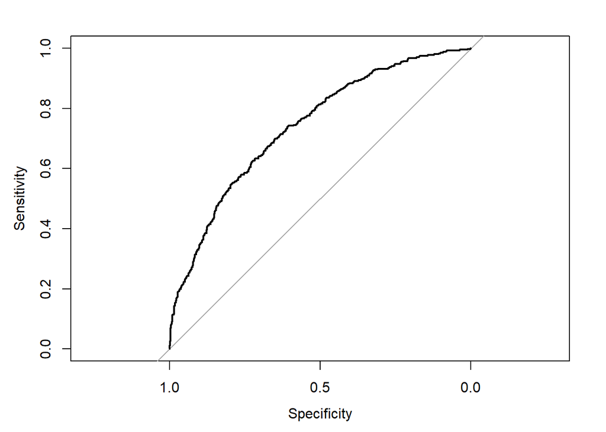

```r
plot(roc_train)
```

##### Area Under Curve.

AUC measures the model’s ability to distinguish between classes (closer to 1 = better).

```r
auc(roc_train)
```

```
## Area under the curve: 0.739
```

### 6. Testing Data Evaluation

#### A. Selecting the testing data

```r
chd_test <- test_data
```

#### B. Prediction based on the training data.

```r
chd_test$predicted_prob <-   predict(reg_test, newdata = chd_test, type = "response")
```

#### C. Extracting binary results.

```r
chd_test <- chd_test %>%
  mutate(
    predicted_class = ifelse(predicted_prob > 0.5, 1, 0)
  )
```

#### D. Developing the confusion matrix.

```r
confusion_test <- table(chd_test$TenYearCHD, chd_test$predicted_class)
confusion_test
```

```
##
##       0   1
##   0 931   6
##   1 157   6
```

#### E. Calculating accuracy

```r
accuracy_test <- sum(diag(confusion_test)) / sum(confusion_test)
accuracy_test
```

```
## [1] 0.8518182
```

#### F. Extracting confusion matrix values.

```r
# Extract the values from the confusion matrix of testing
TN_test <- confusion_test[1, 1]  # True Negatives
FP_test <- confusion_test[1, 2]  # False Positives
FN_test <- confusion_test[2, 1]  # False Negatives
TP_test <- confusion_test[2, 2]  # True Positives

c(TN_test, FP_test, FN_test, TP_train)
```

```
## [1] 931   6 157  38
```

#### G. Calculating sensitivity and specificity.

```r
#Calculate Sensitivity (True Positive Rate)
sensitivity_test <- TP_test / (TP_test + FN_test)

# Calculate Specificity (True Negative Rate)
specificity_test <- TN_test / (TN_test + FP_test)
```

```r
sensitivity_test
```

```
## [1] 0.03680982
```

```r
specificity_test
```

```
## [1] 0.9935966
```

#### H. Calculating TSS value.

```r
TSS_test = sensitivity_test + specificity_test - 1
TSS_test
```

```
## [1] 0.0304064
```

#### I. Developing ROC curve.

```r
library(pROC) # for studying ROC.

roc_test <- roc(chd_test$TenYearCHD, chd_test$predicted_prob )
```

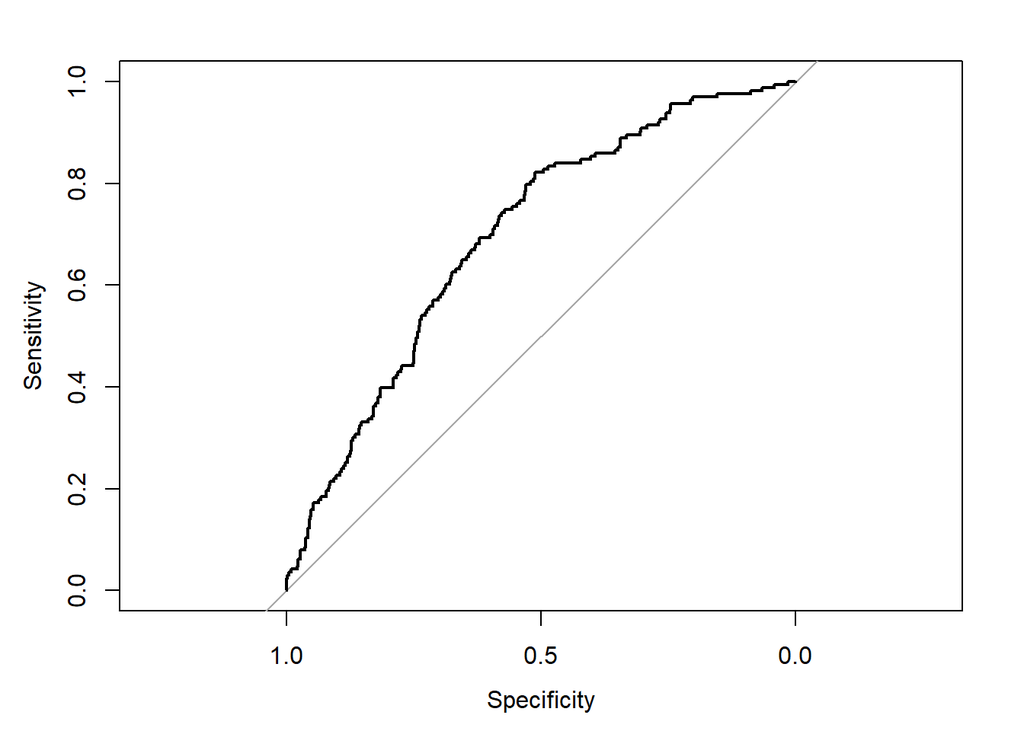

```r
plot(roc_test)
```

#### J. calculating AUC

```r
auc(roc_test)
```

```
## Area under the curve: 0.6959
```

The overall predictive power of the model is quite poor. Even though accuracy is quite fine, TSS is very low, referring that model has no skill at all in predicting the scenario. Therefore, we can’t consider this model in predicting the prevalence or absence of heart disease.

The accuracy is quite high because the model predicts negative (0) cases with a great accuracy, but regarding the positive cases, the model is poor. Hence, the overall TSS is low thereby concluding that the model is not even close to good for predicting the Coronary Heart Disease.